# BARUG3

David Rodriguez

December 16, 2015

# Prerequisites

```r
library(multree)
```

# Intro

### Goal

- Construct a neural decision forest using the `multree` package.

### Conclusion

- The `multree` can used on raw signals.

### Outline

- Prep Data
- Train model
- Predict
- Inspect

# Data - Signals

**Hand Extension Recording**

### Matrix

```r
home <- "~/Desktop/tmp/DavidHolds"
hand.ext <- read.table("~/Desktop/tmp/DavidHolds/Extension_1", sep= ",")[, c(4:10, 3)]
head(hand.ext)
```

```
##   emg.sig1 emg.sig2 emg.sig3 emg.sig4 emg.sig5 emg.sig6 emg.sig7 emg.sig8
## 1       -2       -6       -1      -31       19      -25       -8       -3
## 2        4        8        6       36       17        0        3        3
## 3       -2       -3       14       98      114       37        3        2
## 4        0        5        9       20        0       10        2        2
## 5        2        1      -15      -76      -63      -28       -7       -1
## 6        4        6        6       -4     -110       -4        5        4
```

### Vectorized

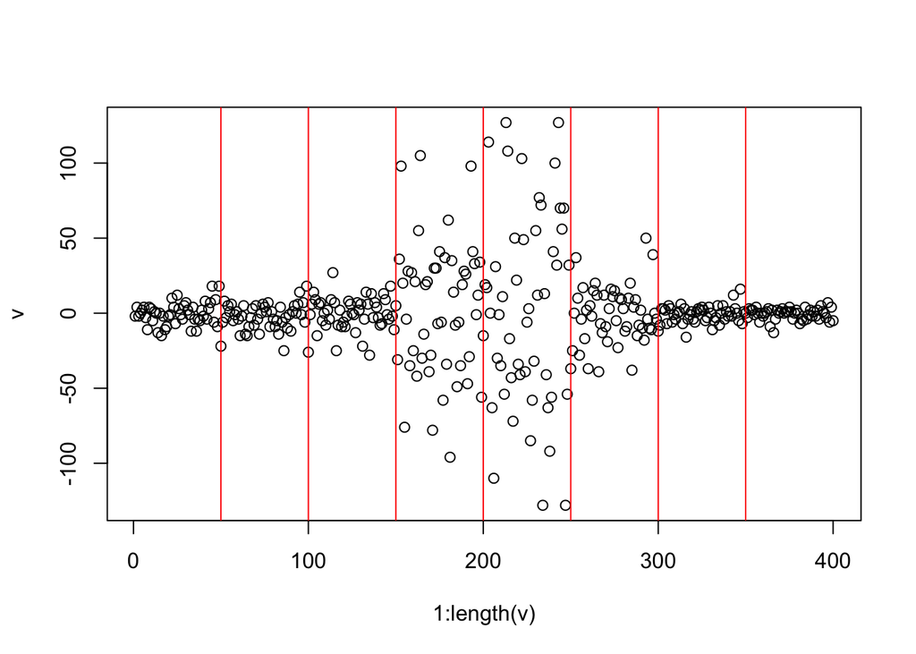

```r
v <- do.call(c, hand.ext)
plot(1:length(v), v)
abline(v = unlist(lapply(1:7, function(x) x*50)), col = "red")
```

## Prep Data

- `X` matrix with rows = one gesture, columns = sample time.
- `Y` vector with gesture labels.

```r
df <- c()
for (file in list.files(home)) {
  a  <- do.call(c, read.table(paste0(home, "/", file), sep= ",")[, c(4:10, 3)])
  df <- rbind(df, c(unlist(strsplit(file, "_"))[1], a))
}

Y <- as.factor(df[,1])
X <- as.data.frame(apply(df[,2:ncol(df)], 1:2, as.numeric))
table(Y)
```

```
## Y
##  Extension    Flexion HandClosed   HandOpen NoMovement  Pronation Supination
##         30         30         30         30         30         29         30
```

# Training/Test Set

Here I’m just constructing a training and testing data set.

```r
test <- sample(1:nrow(X), floor(1/4*nrow(X)))
```

# Forest Presets

So the `multree` package can be trained on vectorized signals.

- We just need to preset the number of random windows per signal.
- And preset features to compute from each window.

```r
feature.space = list(window = "dbars", w = 50, k = 8, low = 10, high= 45, d=2, features = "e")
```

Let’s describe each of these variables:

- `window` denotes we want to duplicate bars over each window.
- `w` denotes how many data points are in a signal frame or window.
- `k` denotes how many signals.
- `low` denotes the smallest random window size.
- `high` denotes the larges random window size.
- `d` denotes the number of random windows.
- `features` denotes the statistic calculated in a random window: i.e. the `e` is standard deviation.

## Train Neural Decision Forest

Now, let’s train a neural decision forest with `70` trees.

```r
fit <- mulforest(Y[-test], X[-test,], "rnet", .99, feature.space = feature.space, size = 70)
```

While this is training, we can go over each of the parts:

- `Y` the vector with class labels.
- `X` the data matrix, rows assigned a label in `Y`.
- `rnet` denotes we want a randomized neural network trained.
- `.99` denotes a leaf is formed with at least 99 percent class purity.
- `feature.space` constructed in previous section.
- `size` the number of trees in a forest.

## Prediction

We now make predictions,

```r
p  <- mf.predict(fit, X[test,])
```

We breakdown the accuracy in a confusion table:

```r
table(Predicted = p, True = Y[test])
```

```
##             True
## Predicted    Extension Flexion HandClosed HandOpen NoMovement Pronation Supination
##   Extension          5       0          0        0          0         0          0
##   Flexion            0       9          0        0          0         4          1
##   HandClosed         0       0          5        0          0         0          0
##   HandOpen           0       0          0        4          0         0          0
##   NoMovement         0       0          0        0          9         0          0
##   Pronation          0       0          2        0          0         5          0
##   Supination         0       0          1        0          0         0          7
```

```r
print(sum(p == Y[test])/length(Y[test]))
```

```
## [1] 0.8461538
```

# Investigating

Using the `force.graph` command we may look at individual tree properties.

```r
force.graph(fit$forest[[1]])
```

[interactive chart not shown]